# Direct benevolence manipulation analysis

Matt Jaquiery (matt.jaquiery@psy.ox.ac.uk)

July 2019

[Script run 2019-10-29 09:32:43]

# Introduction

Observations from [evolutionary models](https://github.com/oxacclab/EvoEgoBias) show that egocentric discounting is a successful strategy in environments where advisors sometimes provide deliberately poor advice. We reason that human participants may show a sensitivity to these contextual factors underlying advice-taking and respond to them in a rational manner. To test the effects of potentially misleading advice, we used a direct benevolence manipulation to pair participant judges in a judge-advisor system with two advisors, one who they were told would consistently try to help them (‘in-group advisor’), and one who they were told may occasionally try to mislead them (‘out-group advisor’).

We hypothesised that participants would place greater weight on the advice of the in-group vs out-group advisor, and that this relationship would be mediated by responses to questionnaires asking about the perceived benevolence of the advisor.

**Version 2.0.0 introduced a much clearer manipulation** by reminding participants of the properties of the advisor (whether they’d always be helpful) in a message the participant had to acknowledge, by keeping the participant’s group visible throughout, and by including one trial on which the outgroup advisor did actually offer misleading advice.

**Version 2.1.0** removed the difference in advice and adjusted the to be consistent (‘may’ rather than ‘will’ sometime mislead…).

# Method

The experimental code is available on [GitHub](https://github.com/oxacclab/ExploringSocialMetacognition), and the experiement can be performed by visiting [https://acclab.psy.ox.ac.uk/~mj221/ESM/ACv2/db.html](https://acclab.psy.ox.ac.uk/~mj221/ESM/ACv2/db.html?PROLIFIC_PID=WriteUp).

# Results

## Exclusions

```
                               InFirst OutFirst
  attnCheckYear outlyingTrials       2        3
  FALSE                             10        8
```

Our final participant list consists of 18 participants who completed an average of 12.00 trials each.

## Task performance

First we offer a characterisation of the task, to provide the reader with a sense of how the participants performed.

### Decisions

Participants offered estimates of the year in which various events took place. The correct answers were always between 1900 and 2000, although the timeline on which participants responded went from 1890 to 2010 in order to allow extra room for advice. Participants answered by dragging a marker onto a timeline which covered a range of 11 years (e.g. 1940-1950). Participants were informed that a correct answer was one in which the marker covered the year in which the event took place.

#### Correctness

Responses are regarded as **correct** if the target year is included within the marker range.

| decision | mean\|m=11 |
| --- | --- |
| first | .324 |
| last | .449 |

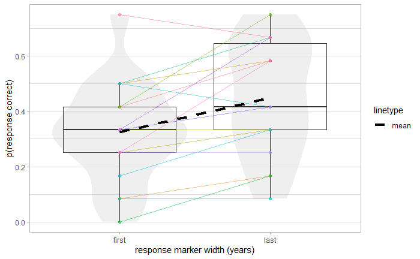

#### Error (estimate mean)

The **error** is calcualted as the distance from the centre of the answer marker to the correct year. It is thus possible for **correct** answers to have non-zero error, and it is likely that the error for correct answers scales with the marker size.

| decision | mean\|m=11 |
| --- | --- |
| first | 18.361 |
| last | 12.931 |

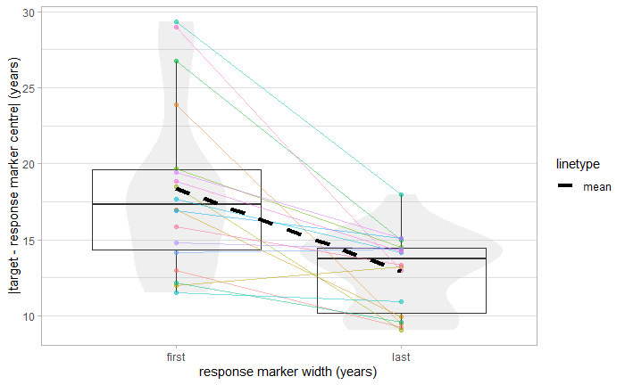

### Timing

We can look at the response time - the difference between the time the response is opened and the time the response is received.

| decision | mean\|m=11 |
| --- | --- |
| first | 8912.745 |
| last | 15157.190 |

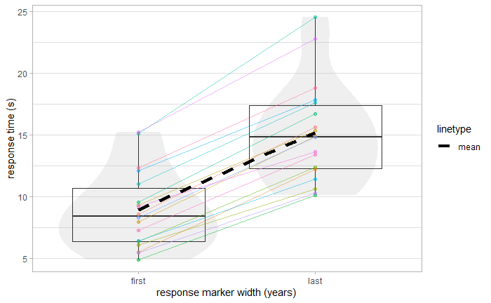

### Summary

Participants took longer on their final decisions, and slightly improved their accuracy. This suggests that they took the time to weigh up the advice, and that they took it into account when making their (final) decisions.

## Advisor performance

The advice offered should be equivalent between in/out group advisors.

### Accuracy

| advisor | accuracy | error |
| --- | --- | --- |
| inGroup | .333 | 8.111 |
| outGroup | .435 | 8.157 |

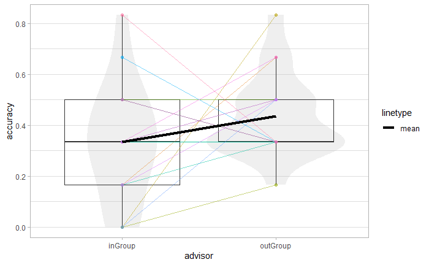

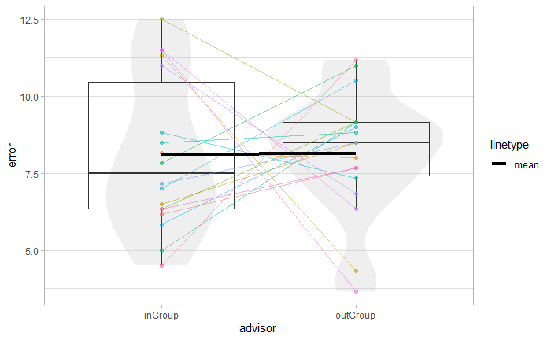

### Agreement

| advisor | agreement |
| --- | --- |
| inGroup | .213 |
| outGroup | .241 |

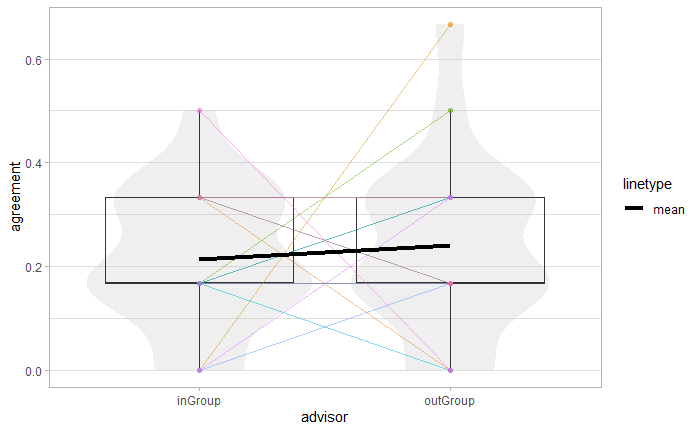

### Distance

Distance is the continuous version of agreement - the difference between the centre of the advice and the centre of the initial estimate.

| advisor | distance |
| --- | --- |
| inGroup | 19.009 |
| outGroup | 16.750 |

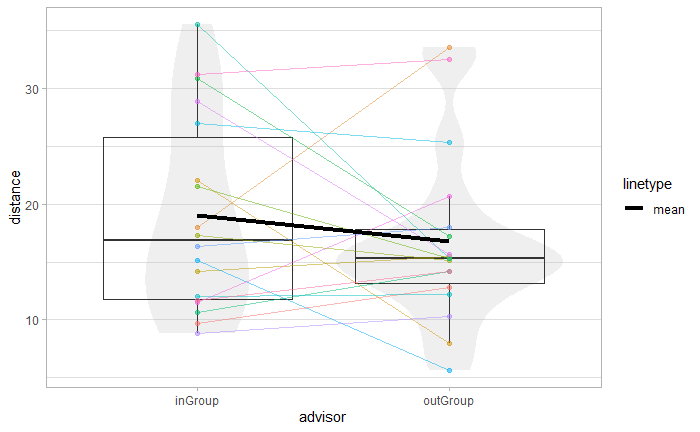

### Summary

The advisors were similar in terms of their objective accuracy and their tendency to offer advice close to the participants’ initial decisions.

### Influence

The measure of influence is weight-on-advice. This is well-defined for values between 0 and 1 (trucated otherwise), and is
$$\text{WoA} = (\text{final} - \text{inital}) / (\text{advice} - \text{initial})$$
, or the degree to which the final decision moves towards the advised answer.

Influence is the primary outcome measure, and is thus expected to differ between advisors and feedback conditions.

| advisor | WoA |
| --- | --- |
| inGroup | .584 |
| outGroup | .335 |

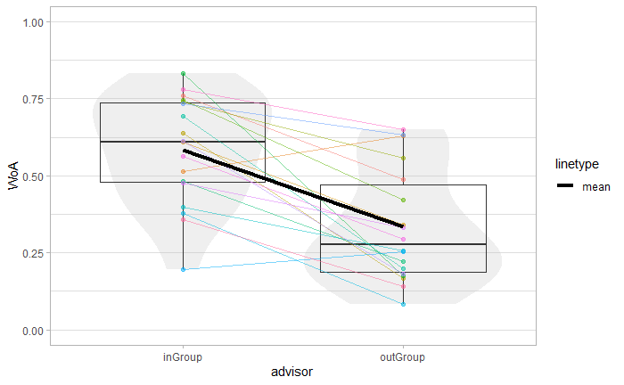

##### WoA distribution

It’s good to keep a general eye on the distribution of weight-on-advice on a trial-by-trial basis.

```
Ignoring unknown parameters: binwidth, bins, pad
```

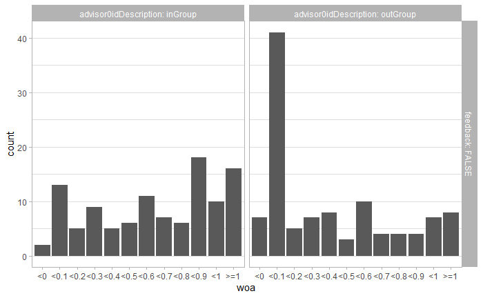

### Summary

Weight on Advice scores differ substantially between the advisors, as do the distributions. While the distributions are quite broad between participants, almost all participants show a marked preference for the inGroup advisor. Formal testing of the hypothesis is below.

## Questionnaire data

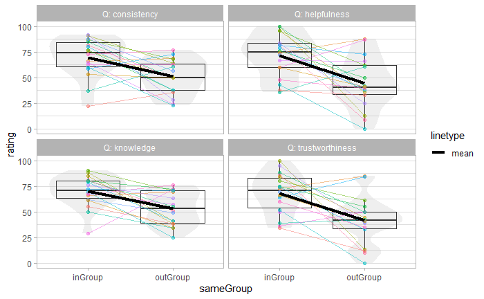

### Summary

Across all questions there is a pronounced preference for the ingroup vs outgroup advisor overall. Some participants do demonstrate higher ratings in some dimensions for the outgroup advisor, however, and the overall difference may be driven by the extent of the response in some participants more than a small consistent difference across participants.

### WoA x Trustworthiness rating

Participants’ trustworthiness ratings should reflect their behavioural measure (weight on advice), such that the extent of advisor preference in one measure should be correlated with the other.

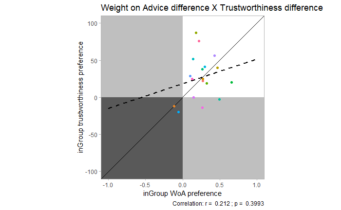

### Summary

A small, non-significant correlation in the expected direct exists between the subjective and objective measures of trust difference.

## Hypothesis testing

The hypotheses being tested here are:

1. Participants will place higher weight on the advice of in-group advisors
2. Participants weighting of advisors by group will be mediated by reports of perceived advisor benevolence

### Group differences

Participants have different weight-on-advice for ingroup as opposed to outgroup advisors.

BF = 752.42; *M*|inGroup = 0.58 [0.50, 0.67], *M*|outGroup = 0.34 [0.24, 0.43]

### Summary

The Bayes factor indicates there is good evidence to support the claim that the participants place greater weight on the advice of inGroup advisor versus the outGroup advisor.

### Questionnaire measure

BF = 27.38; *M*|inGroup = 68.06 [58.20, 77.91], *M*|outGroup = 41.33 [29.89, 52.78]

### Summary

There is also good evidence to support the claim that participants give higher trustworthiness ratings to the inGroup versus outGroup advisor.

### Mediation by benevolence

Initializing model

[output not shown]

[output not shown]

Initializing model

[output not shown]

[output not shown]

|  | Estimate | BF | PostProb |
| --- | --- | --- | --- |
| alpha | 0.50252648 | 25.0834226 | 0.9616615 |
| beta | 0.02662284 | 0.1777248 | 0.1509052 |
| tau_prime | 0.53441510 | 22.6039089 | 0.9576341 |
| Mediation (alpha*beta) | 0.01323607 | 0.1697545 | 0.1451197 |

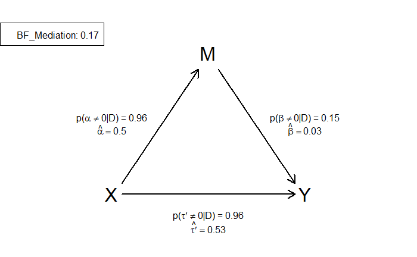

### Summary

These data support the conclusion that advisor group affects both subjective advisor assessment of benevolence (‘helpfulness’), and the extent to which advice is taken, but that the latter is not mediated by the former.

## Exploration

### WoA where advice is taken

We can look at weight on advice for trials where advice is taken: does it still differ between the advisors?

| advisor0idDescription | p.adviceIgnored_m | p.adviceIgnored_sd |
| --- | --- | --- |
| inGroup | 0.1388889 | 0.1641974 |
| outGroup | 0.3981481 | 0.2749860 |

```
There were 24 warnings (use warnings() to see them)
```

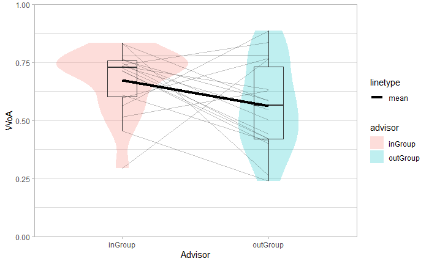

### Advice-taking differences

We want to know whether the lower advice-taking in the outGroup condition is due to reduced advice-taking on each trial, or whether it is due specifically to large reductions in advice-taking on trials where the advice is considered implausible.

If advice is generally discounted, we should see WoA x distance plot lines shifting in intercept but not shape. If it is due to implausible advice being more heavily penalised, we should see similar intercepts but different shapes.

#### Summary

# Conclusions

Through further analysis we may be able to distinguish general wariness of advice from the outGroup advisor from specific discounting of ‘implausible’ advice from the outGroup advisor.

# Credits

## Acknowledgements

Thanks as always to Nick Yeung and the other folks at the [ACC Lab](https://www.psy.ox.ac.uk/research/attention-cognitive-control-lab).

## Funding

Matt Jaquiery is funded by a studentship from the [Medical Research Council](https://mrc.ukri.org/) (reference 1943590) and the University of Oxford [Department of Experimental Psychology](https://www.psy.ox.ac.uk/) (reference 17/18_MSD_661552).